# Effects from severe weather conditions on the population health and the economy in the US for 1950 - 2011

Berthold Jaeck

5/03/2017

## Synopsis

Severe weather events such as Tornados, floods or draughts often cause fatalities among the population and damage to the economy by destroying property or causing crop failure. Developping efficient counter strategies for these event to minimize the death toll and economic damage, it demands a quantitative understanding of the damages induced by such weather events in the past. In this manuscript, we present an quantitative account for the effects of severe weather events on the population health and the economy. For this purpose, we study the climate data set provided on the Coursera course wegpage, which contains records on severe weather events across the United States from 1950-2011. We employ the total amount of fatalities and the property and agricultural damage accumulated across the United States as a probe to study these effects. From a statistical analysis, we find that Tornados are the main cause for both fatalities among the population and property damage. By contrast, 60 % of the agricultural damage is caused by draughts and floods and Tornados only play a minor role. Our study sheds light on the quantitative impact of severe weather events on population health and the economy and could help to devise efficient counter strategies.

## Loading data and libraries

The climate data used for this survey,“repdata-data-StormData.csv.bz2”, is provided within the course material and downloaded from the Coursera webpage on May 3, 2017, 5:45 PM. The data set will be stored in the table dataframe format of the dplyr package.

```r
df<-tbl_df(read.csv("repdata-data-StormData.csv.bz2", header=TRUE))
print(df)
```

```
## # A tibble: 902,297 × 37
##    STATE__           BGN_DATE BGN_TIME TIME_ZONE COUNTY COUNTYNAME  STATE
##      <dbl>             <fctr>   <fctr>    <fctr>  <dbl>     <fctr> <fctr>
## 1        1  4/18/1950 0:00:00     0130       CST     97     MOBILE     AL
## 2        1  4/18/1950 0:00:00     0145       CST      3    BALDWIN     AL
## 3        1  2/20/1951 0:00:00     1600       CST     57    FAYETTE     AL
## 4        1   6/8/1951 0:00:00     0900       CST     89    MADISON     AL
## 5        1 11/15/1951 0:00:00     1500       CST     43    CULLMAN     AL
## 6        1 11/15/1951 0:00:00     2000       CST     77 LAUDERDALE     AL
## 7        1 11/16/1951 0:00:00     0100       CST      9     BLOUNT     AL
## 8        1  1/22/1952 0:00:00     0900       CST    123 TALLAPOOSA     AL
## 9        1  2/13/1952 0:00:00     2000       CST    125 TUSCALOOSA     AL
## 10       1  2/13/1952 0:00:00     2000       CST     57    FAYETTE     AL
## # ... with 902,287 more rows, and 30 more variables: EVTYPE <fctr>,
## #   BGN_RANGE <dbl>, BGN_AZI <fctr>, BGN_LOCATI <fctr>, END_DATE <fctr>,
## #   END_TIME <fctr>, COUNTY_END <dbl>, COUNTYENDN <lgl>, END_RANGE <dbl>,
## #   END_AZI <fctr>, END_LOCATI <fctr>, LENGTH <dbl>, WIDTH <dbl>, F <int>,
## #   MAG <dbl>, FATALITIES <dbl>, INJURIES <dbl>, PROPDMG <dbl>,
## #   PROPDMGEXP <fctr>, CROPDMG <dbl>, CROPDMGEXP <fctr>, WFO <fctr>,
## #   STATEOFFIC <fctr>, ZONENAMES <fctr>, LATITUDE <dbl>, LONGITUDE <dbl>,
## #   LATITUDE_E <dbl>, LONGITUDE_ <dbl>, REMARKS <fctr>, REFNUM <dbl>
```

## Data Processing

In this report, we are interested in the effects of severe weather conditions on population health and economy. Hence, we are mainly interested in the variables *FATALITIES*, *PROPDMG* and *CROPDMG* as well as the corresponding scaling variables *PROPDMGEXP* and *CROPDMGEXP*. Accordingly, we will select the repsective columns to reduce the data set.

Looking at the levels of the factor variable EVTYPE, we see that there are 985 factors. Since our goal is to provide the audience a quick summary on the weather data, we’ll filter our data to only show top 10 events of severe weather conditions.

Regarding the scaling variables *PROPDMGEXP* and *CROPDMGEXP*, we will filter only for indicating thousands, *K* and millions, *M* of dollars. In the next step, we multiply each entry of *PROPDMG* and *CROPDMG* by the respective factor scaling factor to obtain the actual dollar value.

After these data processing steps are taken, we calculate the sums of *FATALITIES*, *PROPDMG* and *CROPDMG* broken down into event types.

```r
# select fatality data, calculate sums and filter for top 10 events
df %>% group_by(EVTYPE) %>% summarise(tot.fat=sum(FATALITIES)) %>% filter(tot.fat>206) %>% arrange(desc(tot.fat)) ->df.fatalities.top10


# select property damage data and filter scaling variable
df %>% select(EVTYPE, PROPDMG, PROPDMGEXP) %>% filter(!PROPDMG==0) %>% filter (PROPDMGEXP=="K" | PROPDMGEXP=="M")-> df.prop

# cleaning the event levels
df.prop$EVTYPE<- gsub("TSTM WIND", "THUNDERSTORM WIND", df.prop$EVTYPE)

# Scale the PROPDMG variable to obtain USD value
df.prop %>% mutate(total=ifelse(PROPDMGEXP=="K", 1000*PROPDMG, 1000000*PROPDMG)) -> df.prop

# calculate property damage sums and filter for top 10 events
df.prop %>% group_by(EVTYPE) %>% summarise(propdamage=sum(total)) %>% arrange(propdamage) %>% filter(propdamage>2553890550) -> prop.dmg

# select crop damage data and filter scaling variable
df %>% select(EVTYPE, CROPDMG, CROPDMGEXP) %>% filter(!CROPDMG==0) %>% filter (CROPDMGEXP=="K" | CROPDMGEXP=="M")-> df.crop

# cleaning the event levels
df.crop$EVTYPE<- gsub("TSTM WIND", "THUNDERSTORM WIND", df.crop$EVTYPE)

# Scale the CROPDMG variable to obtain USD value
df.crop %>% mutate(total=ifelse(CROPDMGEXP=="K", 1000*CROPDMG, 1000000*CROPDMG)) -> df.crop

# calculate crop damage sums and filter for top 10 events
df.crop %>% group_by(EVTYPE) %>% summarise(cropdamage=sum(total)) %>% arrange(cropdamage) %>% filter(cropdamage>678346000) -> crop.dmg
```

## Results

### Effects of severe weather events on population health

To understand the effect of severe wheather events on popuation health, we plot the total amount of fatalities in the United states from 1950-2011 in Fig.1 broken down into the respective events. As can be seen, Tornados make the largest contribution to the total fatalities with a death toll of 5633, outnumbering the second largest contributor, excessive heat with a death toll of 1903 by a factor of three. The Tornado death toll is almost as high as the total death toll from all the nine other events of 6448.

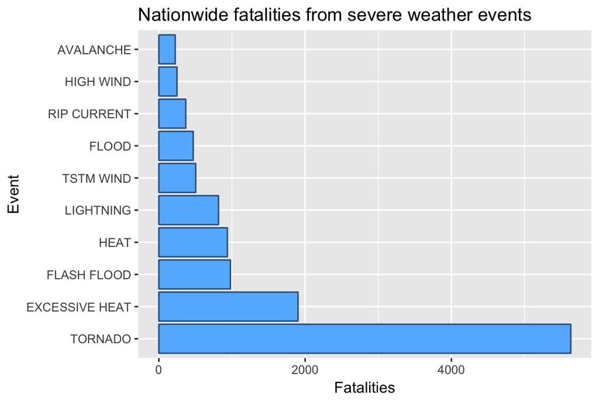

Fig. 1: Total fatalities resulting from severe weather events in the United States from 1950-2011.

```r
df.fatalities.top10$fac<-factor(df.fatalities.top10$EVTYPE, levels=df.fatalities.top10$EVTYPE)

g<-ggplot(df.fatalities.top10, aes(x=fac, y=tot.fat))+geom_bar( stat="identity", col="steelblue4", fill="steelblue1")+labs(title="Nationwide fatalities from severe weather events")+
    labs(y="Fatalities")+labs(x="Event")+coord_flip()
print(g)
```

### Effects of severe weather events on the economy

To understand the effect of severe wheather events on the economy, we plot the total amount of property damage broken down into the respective events in the United States from 1950-2011 in Fig.2. As was the case for the fatalities, also the economy suffers the most from Tornados causing an accumulated property damage exceeding USD 50 billions over the 60 year period. However, we see that flash floods, floods and hail also cause significant property damage. In total, property equal an amount of USD 132.4338452 billions was damaged in the United States over this period.

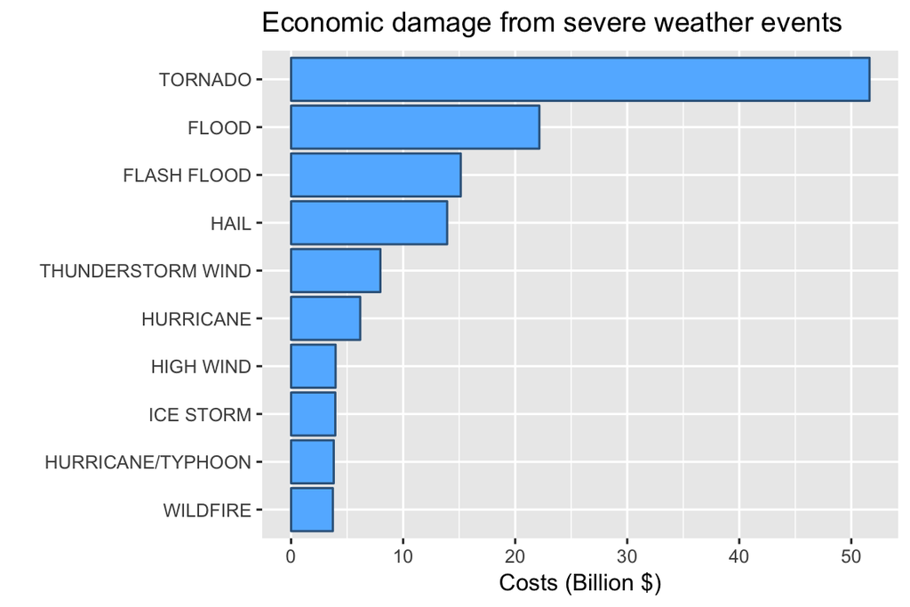

Fig.2: Total property damage resulting from severe weather events in the United States from 1950-2011.

```r
prop.dmg$fac<-factor(prop.dmg$EVTYPE, levels=prop.dmg$EVTYPE)

g<-ggplot(prop.dmg, aes(x=fac, y=propdamage*1e-9))+geom_bar( stat="identity", col="steelblue4", fill="steelblue1")+labs(title="Economic damage from severe weather events")+labs(y="Costs (Billion $)")+labs(x="")+coord_flip()
print(g)
```

In addition, we plot the total amount of agricultural damage caused by severe weather events broken down into the respective events in the United States from 1950-2011 in Fig.3. In contrast to fatalities and property damage, agricultural damage is mostly caused by droughts and floods accounting for 59.4370651% of the total damage that corresponds to USD 30.510481 billions.

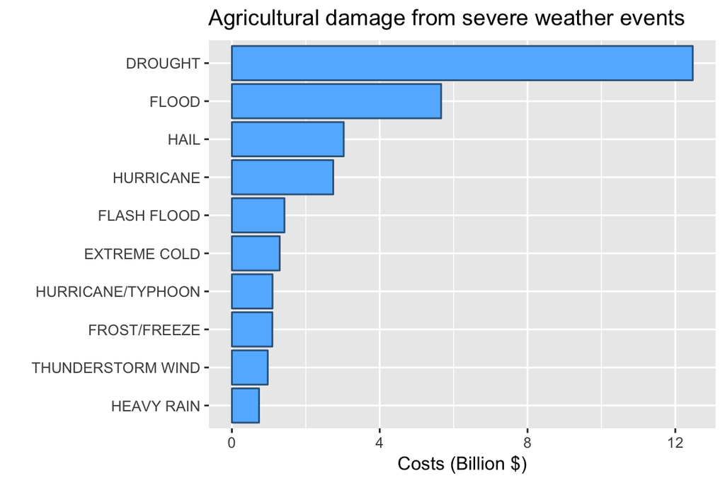

Fig.3: Total agricultural damage resulting from severe weather events in the United States from 1950-2011.

```r
crop.dmg$fac<-factor(crop.dmg$EVTYPE, levels=crop.dmg$EVTYPE)

g<-ggplot(crop.dmg, aes(x=fac, y=cropdamage*1e-9))+geom_bar( stat="identity", col="steelblue4", fill="steelblue1")+labs(title="Agricultural damage from severe weather events")+labs(y="Costs (Billion $)")+labs(x="")+coord_flip()
print(g)
```

## Discussion & Conclusion

The following discussion will only focus on the main events that cause fatalities among the population and damage to property and agriculture. A detailed analysis would lie beyond the scope of this work. We start our discussion by comparing the results from the effects of severe weather events on population health and property shown in Fig.1 and 2, respectively. As can be seen, Tornados are the main contributing event in both cases causing almost 50 % of the total fatalities and 38.9822257% of the total property damage. Hence, investing resources into tornado shelter could help reduce the death toll significantly. Also, dedicating resources to Tornado-safe infrastructure, such as under-ground power grids and land lines, and personal housing, such as wind-proof building structures, could help to reduce the economic impact of this event.

Looking at the data of agricultural damage induced by severe weather event, we can observe a different picture. Here, 59.4370651% of the damage is caused by droughts and flood events. While droughts may be difficult to fight, a possible starting point to reduce the impact of severe weather events on agriculture were to dedicate resources into flood protection. For instance, building dikes and reservoirs would help to manage heavy rainfalls and, at the same time allow to store water resources for the dry season. As an additional effect, handling heavy rainfall by means of dikes and reservoirs would also help to reduce the large impact of flood events on property damage shown in Fig. 2.